## Load datasets

```python
import pandas as pd
trips = pd.read_csv('https://storage.googleapis.com/datalynn-datasets/interview-challenge/technology/Uber_1_Shawn/trips.csv')
cities = pd.read_csv('https://storage.googleapis.com/datalynn-datasets/interview-challenge/technology/Uber_1_Shawn/cities.csv')
drivers_df = pd.read_csv('https://storage.googleapis.com/datalynn-datasets/interview-challenge/technology/Uber_1_Shawn/drivers.csv')
```

# Part 1 SQL syntax

**Q1** Calculate the mean and standard deviation of the difference between Actual and Predicted ETA for all completed trips in the cities 'Qarth' and 'Meereen'. (SQL)

**Answers:**

```python
import sqlite3
import pandas as pd

# Connect to the SQLite in-memory database
conn = sqlite3.connect(':memory:')

# Convert your Pandas dataframes to SQL tables
trips.to_sql('trips', conn, if_exists='replace', index=False)
cities.to_sql('cities', conn, if_exists='replace', index=False)

# Define the queries
query1 = """
    SELECT
        cities.city_name,
        AVG(trips.actual_eta - trips.predicted_eta) as mean_diff,
        (SUM((trips.actual_eta - trips.predicted_eta -
             (SELECT AVG(trips.actual_eta - trips.predicted_eta)
              FROM trips
              WHERE
                  trips.status = 'completed'
                  AND cities.city_name IN ('Qarth', 'Meereen')
              )
             ) * (trips.actual_eta - trips.predicted_eta -
                  (SELECT AVG(trips.actual_eta - trips.predicted_eta)
                   FROM trips
                   WHERE
                       trips.status = 'completed'
                       AND cities.city_name IN ('Qarth', 'Meereen')
                   )
                  )
             )
        / COUNT(trips.id)
        ) as stddev_diff
    FROM
        trips
    JOIN
        cities ON trips.city_id = cities.city_id
    WHERE
        trips.status = 'completed'
        AND cities.city_name IN ('Qarth', 'Meereen')
    GROUP BY
        cities.city_name;
"""


# Execute the queries and store the results in Pandas dataframes
result1 = pd.read_sql_query(query1, conn)
result1
```

|  | city_name | mean_diff | stddev_diff |
| --- | --- | --- | --- |
| 0 | Meereen | 0.184211 | 104.897789 |
| 1 | Qarth | 0.580645 | 92.484711 |

**Q2**. A ride is defined as an event labeled `completed` within the `trips` table. For each city ('Qarth' and 'Meereen') and each day of the week, determine the percentage of rides in the first quarter of 2016 that had a client rating above 4. (SQL)

**Answers:**

```python
query2 = """
    SELECT
        cities.city_name,
        strftime('%w', trips.request_at) as day_of_week,
        AVG(CASE WHEN trips.client_rating > 4 THEN 1 ELSE 0 END) as percentage_above_4
    FROM
        trips
    JOIN
        cities ON trips.city_id = cities.city_id
    WHERE
        trips.status = 'completed'
        AND trips.request_at >= '2016-01-01'
        AND trips.request_at < '2016-04-01'
        AND cities.city_name IN ('Qarth', 'Meereen')
    GROUP BY
        cities.city_name,
        day_of_week;
"""

result2 = pd.read_sql_query(query2, conn)

# Close the connection to the database
conn.close()
result2
```

|  | city_name | day_of_week | percentage_above_4 |
| --- | --- | --- | --- |
| 0 | Meereen | 0 | 0.000000 |
| 1 | Meereen | 1 | 0.000000 |
| 2 | Meereen | 2 | 0.000000 |
| 3 | Meereen | 3 | 0.153846 |
| 4 | Meereen | 4 | 0.000000 |
| 5 | Meereen | 5 | 0.200000 |
| 6 | Meereen | 6 | 0.166667 |
| 7 | Qarth | 0 | 0.200000 |
| 8 | Qarth | 1 | 0.333333 |
| 9 | Qarth | 2 | 0.200000 |
| 10 | Qarth | 3 | 0.000000 |
| 11 | Qarth | 4 | 0.285714 |
| 12 | Qarth | 5 | 0.375000 |
| 13 | Qarth | 6 | 0.500000 |

# Part 2.Experiment Design

Suppose the Driver Experience team is considering a new "Streak Bonus" feature, where drivers are rewarded for completing a certain number of trips in a row without cancellations.

**Q3** Propose a measurable definition of 'engagement' in this context. What kind of data would you need to track this metric effectively?

**Answers:** In this context, 'engagement' could be defined as the number of trips a driver completes without cancellations over a given time period. This could be a week or a month, depending on the granularity of the data available. A higher number of completed trips would indicate a higher level of engagement.

**Q4** Assuming we have a baseline measure of driver engagement before implementing the "Streak Bonus," how would you design an experiment to test whether this feature increases driver engagement? What statistical methods would you consider to determine if the change in engagement is significant?

**Answers:** To track this effectively, we would need data on each trip a driver takes, the outcome of the trip (completed or cancelled), the time the trip occurred, and whether the driver was enrolled in the "Streak Bonus" program at the time.

For the experiment design, we could use an A/B testing approach. We would randomly split drivers into two groups: a control group that doesn't have access to the "Streak Bonus" feature, and a test group that does. Both groups would be similar in terms of demographics, average completed trips per week, and other relevant metrics to reduce bias. We would then monitor both groups for a certain period (for example, a month), and measure the difference in engagement between the two groups.

For statistical analysis, we could use a two-sample t-test to compare the means of the two groups. The null hypothesis would be that there's no difference in engagement between the two groups, and the alternative hypothesis would be that there is a difference.

# Part 3 Data analysis

Imagine that you're an Uber data scientist with access to a vast dataset of drivers. This dataset includes sign-up details, trip records, rating history, and more.

Table Name: **`drivers`**

| Field | Description |
| --- | --- |
| id | Driver ID |
| city_id | ID of the city where the user signed up |
| signup_os | Signup device of the user (possible values: "android", "ios", "website", "other") |
| signup_timestamp | Timestamp of account creation, represented in local time in the form 'YYYY/MM/DD' |
| bgc_date | Date of background check consent, represented in the form 'YYYY/MM/DD' |
| vehicle_added_date | Date when driver's vehicle information was uploaded, represented in the form 'YYYY/MM/DD' |
| first_trip_date | Date of the first trip as a driver, represented in the form 'YYYY/MM/DD' |
| vehicle_make | Make of vehicle uploaded (e.g., Honda, Ford, Kia) |
| vehicle_model | Model of vehicle uploaded (e.g., Accord, Prius, 350z) |
| vehicle_year | Year that the car was made, represented in the form 'YYYY' |
| total_trips | Total trips taken by the driver in the past year |

**Q5** In provided driving journey, some drivers exhibit higher activity levels (**`total_trips`** feature from Table **`drivers`**) than others. From a business perspective, understanding what contributes to this disparity can be quite valuable. Can you derive a way to evaluate these differences? How would you investigate the connection between these factors and the previously evaluated differences in driver activity? (Python)

**Answers:**

```python
import pandas as pd

# Load the dataset

# To analyze the relationship between activity levels and signup devices
activity_signup_os = drivers_df.groupby('signup_os')['total_trips'].mean().sort_values(ascending=False)
print("Average activity level by signup device:")
print(activity_signup_os)

# To analyze the relationship between activity levels and city IDs
activity_city = drivers_df.groupby('city_id')['total_trips'].mean().sort_values(ascending=False)
print("Average activity level by city:")
print(activity_city)

# To analyze the relationship between activity levels and type of car
activity_vehicle = drivers_df.groupby(['vehicle_year'])['total_trips'].mean().sort_index(ascending=False)
print("Average activity level by vehicle:")
print(activity_vehicle)
```

```
Average activity level by signup device:
signup_os
ios        390.925926
android    206.526749
website    201.088000
other      194.511364
Name: total_trips, dtype: float64
Average activity level by city:
city_id
9     481.972222
5     475.227273
7     209.049505
3     201.223404
6     198.108696
1     193.622222
4     183.198113
8     181.600000
10    180.972727
2     177.702970
Name: total_trips, dtype: float64
Average activity level by vehicle:
vehicle_year
2023    142.181818
2022    144.223684
2021    141.288136
2020    189.828125
2019    148.405797
2018    215.794521
2017    222.298701
2016    242.222222
2015    248.880597
2014    307.554054
2013    329.405405
2012    342.432432
2011    394.710526
2010    363.411765
Name: total_trips, dtype: float64
```

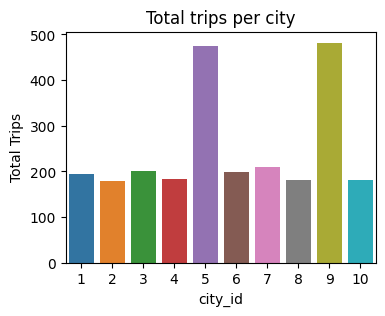

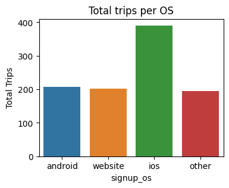

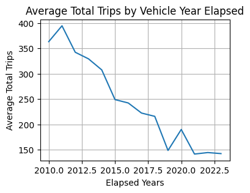

```python
from numpy.lib import average
import seaborn as sns
import matplotlib.pyplot as plt

# Convert 'signup_timestamp' to datetime
drivers_df['signup_timestamp'] = pd.to_datetime(drivers_df['signup_timestamp'])

# Plot 'total_trips' against 'city_id'
plt.figure(figsize=(4, 3))
sns.barplot(x='city_id', y='total_trips', data=drivers_df, estimator='mean', errorbar= None)
plt.title('Total trips per city')
plt.ylabel('Total Trips')
plt.show()

# Plot 'total_trips' against 'signup_os'
plt.figure(figsize=(4, 3))
sns.barplot(x='signup_os', y='total_trips', data=drivers_df, estimator='mean', errorbar=None)
plt.title('Total trips per OS')
plt.ylabel('Total Trips')
plt.show()

# Plot the results
plt.figure(figsize=(4, 3))
plt.plot(activity_vehicle.index, activity_vehicle.values)
plt.xlabel('Elapsed Years')
plt.ylabel('Average Total Trips')
plt.title('Average Total Trips by Vehicle Year Elapsed')
plt.grid(True)
plt.show()
```

## 3.2 Based on the trends and patterns you have discovered in the data, how can you predict the number of trips a new driver will complete? (Python)

**Answers:**

```python
from scipy.optimize import LinearConstraint
from sklearn.model_selection import train_test_split
from sklearn.preprocessing import OneHotEncoder
from sklearn.ensemble import RandomForestRegressor
from sklearn.metrics import mean_squared_error
from sklearn.preprocessing import StandardScaler
from sklearn.linear_model import LinearRegression
from sklearn.ensemble import GradientBoostingRegressor


df = drivers_df.copy()
s_date = pd.to_datetime('2010-01-01')
# Convert dates to numerical format by extracting date features
for column in ["signup_timestamp", "bgc_date", "vehicle_added_date", "first_trip_date"]:
    df[column] = pd.to_datetime(df[column])
    df[column + 'elapsed'] = (df[column] - s_date).dt.days

# Now you can drop the original datetime columns
df = df.drop(["signup_timestamp", "bgc_date", "vehicle_added_date", "first_trip_date"], axis=1)

# One-hot encode categorical variables
encoder = OneHotEncoder()
encoded_df = pd.DataFrame(encoder.fit_transform(df[["signup_os", "vehicle_make", "vehicle_model", "city_id"]]).toarray())

# Combine the encoded features with the rest of the dataset
df = df.drop(["signup_os", "vehicle_make", "vehicle_model", "id", "city_id"], axis=1)
df = pd.concat([df, encoded_df], axis=1)


# Split the data into a training set and a testing set
X_train, X_test, y_train, y_test = train_test_split(df.drop("total_trips", axis=1), df["total_trips"], test_size=0.2, random_state=42)
X_train = X_train.to_numpy()
X_test = X_test.to_numpy()

# Standarization
scaler = StandardScaler()
X_train = scaler.fit_transform(X_train)
X_test = scaler.transform(X_test)


# Train a Random Forest Regressor
model = GradientBoostingRegressor()
model.fit(X_train, y_train)


# Use the trained model to make predictions on the test set
predictions = model.predict(X_test)


mse_train = mean_squared_error(y_train, model.predict(X_train))
print("Mean Squared Error (train):", mse_train)

# Evaluate the model
mse = mean_squared_error(y_test, predictions)
print("Mean Squared Error:", mse)
```

```
Mean Squared Error (train): 23.122572255739687
Mean Squared Error: 98.02519309737177
```

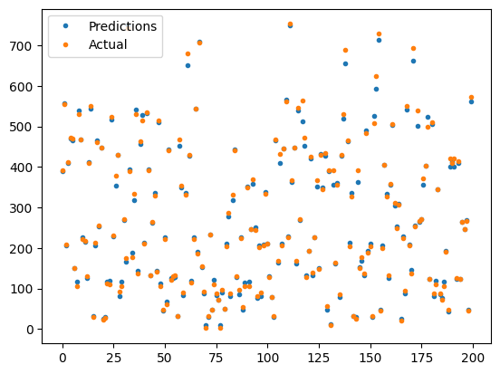

```python
import numpy as np
import pandas as pd
import matplotlib.pyplot as plt
import seaborn as sns

plt.plot(range(len(predictions)) ,predictions,'.', label='Predictions')
plt.plot(range(len(y_test)),y_test,'.', label='Actual')
plt.legend()
plt.show()
```